# Cobb Douglas Production Function: Non Linear Optimization

Carlos Pelayo

4/24/2020

## non-linear optimization

This Rmarkdown file demonstrates techniques for non-linear optimization, and is illustrated with data for the Cobb-Douglas production function, $y = A K^\alpha L^\beta$, K capital, L labor, and the exponents the elasticies of production by input.

### Methods demonstrated:

1. Grid search of space of parameters
2. non-linear optimization software, find values of the parameters that minimize the sum of squared errors, errors are (data-predicted)
3. non-linear optimizatin software, maximum likelihood- find values of the parameters that maximize the likelihood of the data assuming errors are normally distributed
4. log-transform to a linear model

Read in the data

```r
CobbDoug = read.csv('CobbDouglasData.csv')
attach(CobbDoug)
```

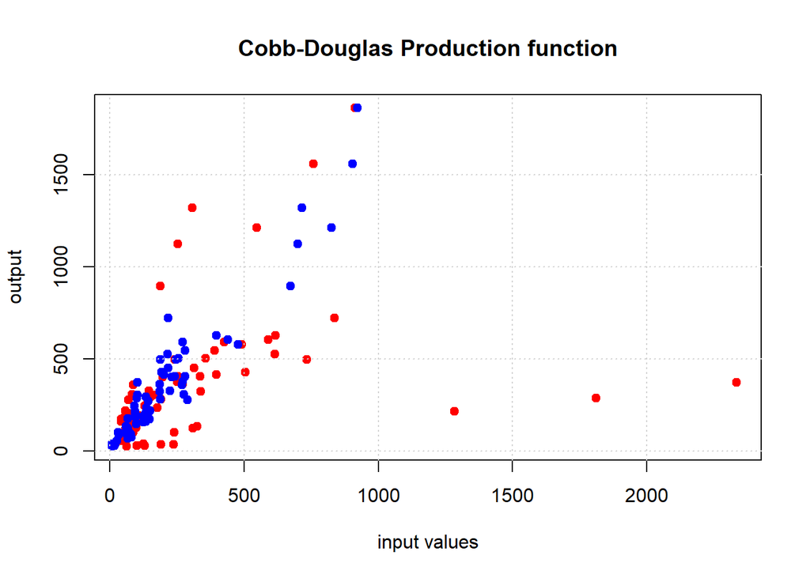

```r
plot(Cap, Q, pch=19, col='red', xlab= 'input values', ylab = 'output',
     main='Cobb-Douglas Production function')
points(Emp, Q, pch=19, col='blue')
grid()
```

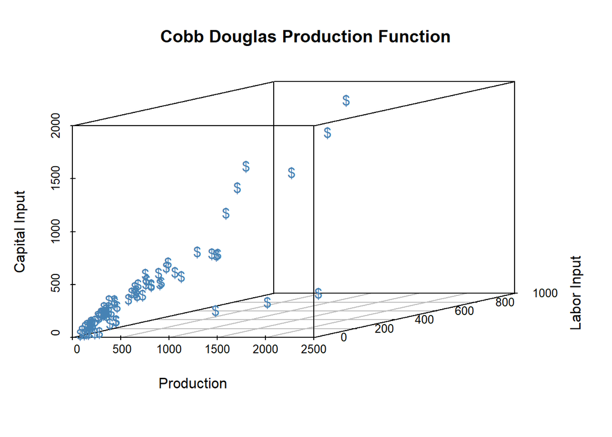

```r
scatterplot3d(x=Cap,y=Emp,z=Q,color="steelblue",pch="$",angle=15, main="Cobb Douglas Production Function", xlab="Production",ylab="Labor Input",zlab="Capital Input",grid=TRUE)
```

Set up a non-linear loss function

```r
CDloss=function(parms, Q, Cap, Emp){

  A = parms[1]
  alpha = parms[2]
  beta = parms[3]

  Loss = 0
  for (i in 1:length(Q)){
    Loss = Loss + ((Q[i]-A*(Cap[i]^beta*Emp[i]^alpha))^2)
  }

  return (log(Loss))
}

CDmle=function(parms, Q, Cap, Emp){
  A = parms[1]
  alpha = parms[2]
  beta = parms[3]

  logLoss = 0
  for (i in 1:length(Q)){
    errorTerm= (Q[i]-A*(Cap[i]^beta*Emp[i]^alpha))
    logLoss = logLoss - dnorm(errorTerm, log=T)
  }

  return (log(logLoss))
}
```

Test the loss function

```r
A = 1
alpha = 0.5
beta = 0.5
parms=c(A, alpha, beta)
print(CDloss(parms, Q, Cap, Emp))
```

```
## [1] 15.2447
```

```r
# better or worse than
A = 0.75
alpha = 0.2
beta = 0.5
parms=c(A, alpha, beta)
print(CDloss(parms, Q, Cap, Emp))
```

```
## [1] 16.54906
```

## Grid search

not the best idea, can get close to an answer

```r
for (A in seq(from=0.1, to = 3, length.out = 4))
  for(a in seq(from=0.1, to = 1,length.out = 4))
   for(b in seq(from=0.1, to = 1, length.out = 4)){
     parms = c(A, a, b)
      print(paste(A,"/" ,a,"/", b,"/", CDloss(parms, Q, Cap, Emp)))
  }
```

```
## [1] "0.1 / 0.1 / 0.1 / 16.6847489118011"
## [1] "0.1 / 0.1 / 0.4 / 16.6802777708103"
## [1] "0.1 / 0.1 / 0.7 / 16.6515818764994"
## [1] "0.1 / 0.1 / 1 / 16.4632640411232"
## [1] "0.1 / 0.4 / 0.1 / 16.6804078987793"
## [1] "0.1 / 0.4 / 0.4 / 16.65346517855"
## [1] "0.1 / 0.4 / 0.7 / 16.4722250123247"
## [1] "0.1 / 0.4 / 1 / 15.5542069769201"
## [1] "0.1 / 0.7 / 0.1 / 16.6531706496799"
## [1] "0.1 / 0.7 / 0.4 / 16.4742924886007"
## [1] "0.1 / 0.7 / 0.7 / 14.9002109873752"
## [1] "0.1 / 0.7 / 1 / 19.4900306431978"
## [1] "0.1 / 1 / 0.1 / 16.4663067313885"
## [1] "0.1 / 1 / 0.4 / 14.7244921354164"
## [1] "0.1 / 1 / 0.7 / 19.3154443183495"
```

[output cut: 49 more lines]

## non linear optimization

use function optim to find values of A, alpha, beta find values that minimize the loss function, loss = sum of sqrared errors. This is a ‘least squares’ solution

```r
### Optimization
parms = c(1, 0.75, 0.25)
opt = optim(parms, CDloss,Q=Q,Cap=Cap,Emp=Emp)
print(opt)
```

```
## $par
## [1] 1.3034307 0.8287611 0.2216129
##
## $value
## [1] 12.97694
##
## $counts
## function gradient
##      140       NA
##
## $convergence
## [1] 0
##
## $message
## NULL
```

```r
parms = c(opt$par[1], opt$par[2], opt$par[3])
print(CDloss(parms, Q, Cap,Emp))
```

```
## [1] 12.97694
```

## transform to logs

```r
logModel = glm(log(Q)~log(Cap)+log(Emp))
summary(logModel)
```

```
##
## Call:
## glm(formula = log(Q) ~ log(Cap) + log(Emp))
##
## Deviance Residuals:
##      Min        1Q    Median        3Q       Max
## -0.44625  -0.14466   0.03981   0.12703   0.45446
##
## Coefficients:
##             Estimate Std. Error t value Pr(>|t|)
## (Intercept)  0.54032    0.15151   3.566 0.000663 ***
## log(Cap)     0.23234    0.02882   8.061 1.55e-11 ***
## log(Emp)     0.76531    0.02735  27.980  < 2e-16 ***
## ---
## Signif. codes:  0 '***' 0.001 '**' 0.01 '*' 0.05 '.' 0.1 ' ' 1
##
## (Dispersion parameter for gaussian family taken to be 0.04720648)
##
##     Null deviance: 64.5844  on 71  degrees of freedom
## Residual deviance:  3.2572  on 69  degrees of freedom
## AIC: -10.569
##
## Number of Fisher Scoring iterations: 2
```

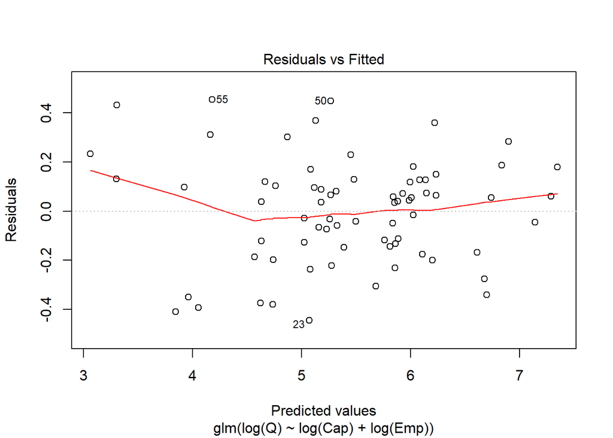

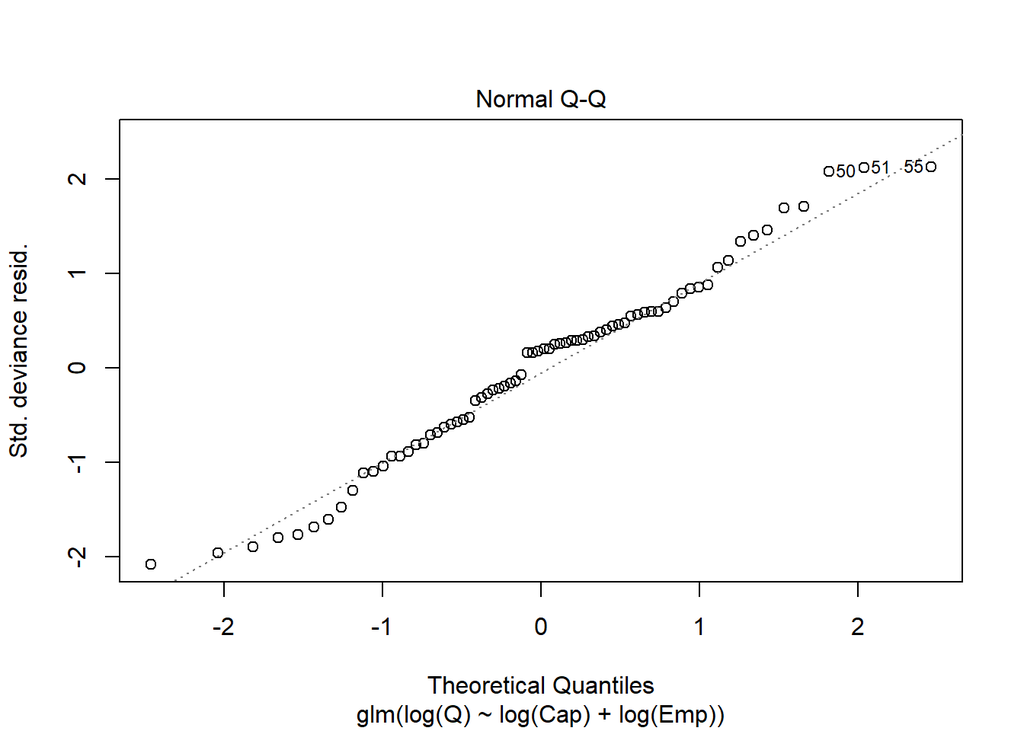

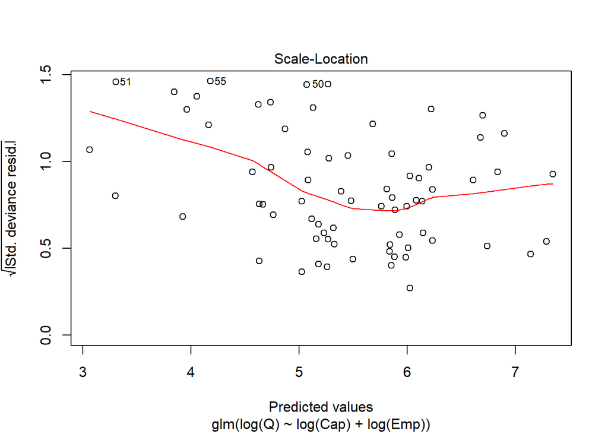

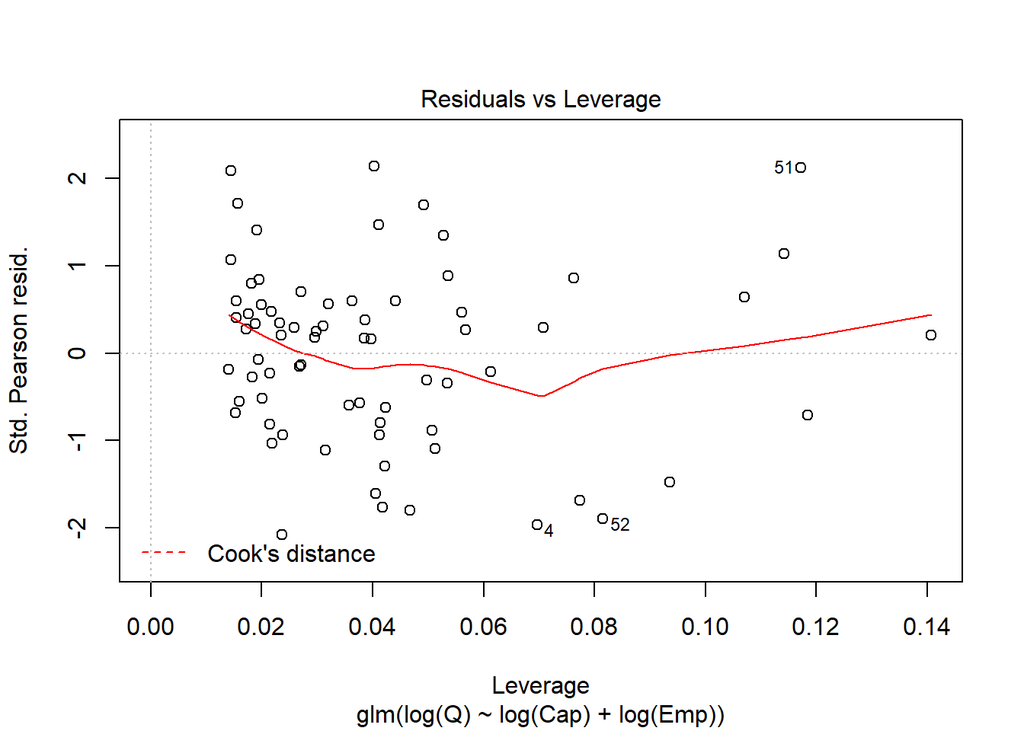

```r
plot(logModel)
```

```r
A = exp(logModel$coefficients[1])
alpha = logModel$coefficients[2]
beta = logModel$coefficients[3]
print(paste('A = ',A,' alpha = ', alpha,' beta =', beta))
```

```
## [1] "A =  1.71655367062008  alpha =  0.232343040964735  beta = 0.765310412619359"
```

```r
# CD loss at these values:
parms=c(A, alpha, beta)
print(paste('CD loss: ', CDloss(parms, Q, Cap, Emp)))
```

```
## [1] "CD loss:  15.7914789583455"
```

## maximum likelihood estimation

$\phi$ is the standard normal distribution

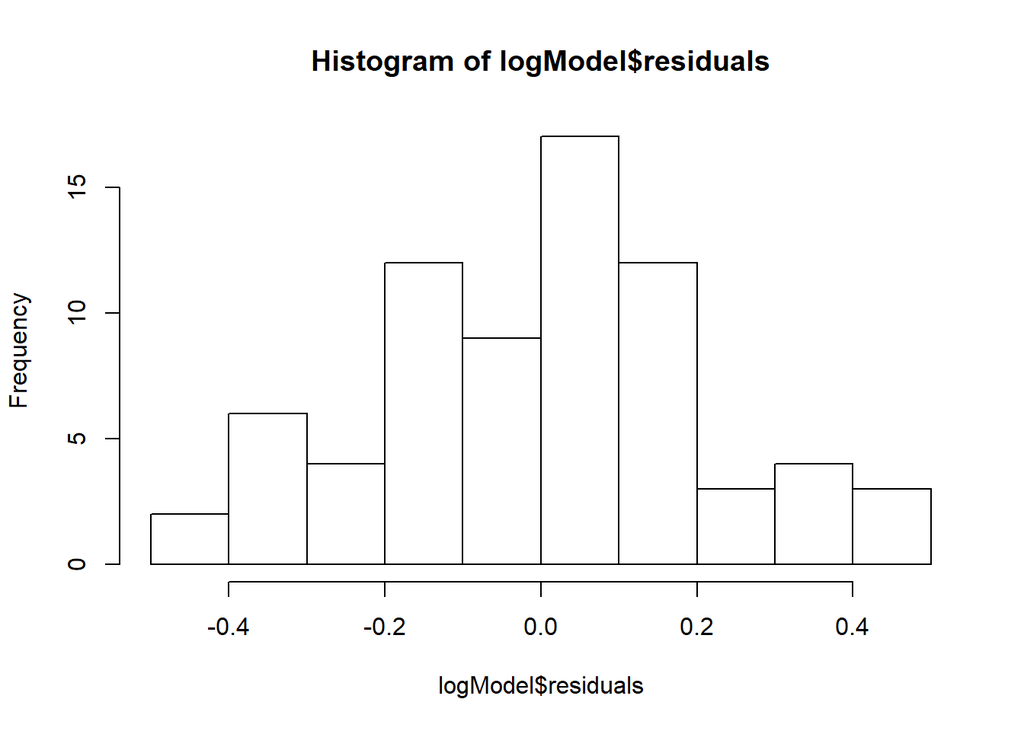

```r
hist(logModel$residuals)
```

```r
parms = c(2, 0.8, 0.2)
opt = optim(parms, CDmle, Q=Q, Cap=Cap, Emp=Emp)
print(opt)
```

```
## $par
## [1] 1.3044599 0.8287067 0.2215366
##
## $value
## [1] 12.2841
##
## $counts
## function gradient
##      170       NA
##
## $convergence
## [1] 0
##
## $message
## NULL
```

```r
parms = c(opt$par[1], opt$par[2], opt$par[3])
print(CDmle(parms, Q, Cap,Emp))
```

```
## [1] 12.2841
```

## Questions:

### 1. what are the estimated values of A, alpha and beta?

```
In order to minimize the loss function, the values for the constants are as follow: $A$=1.3044599, $\alpha$=0.8287067, $\beta$=0.2215366. The result was acheieved by using the Maximum Likelihood estimation method.
```

### 2. Confidence intervals on A, alpha, beta?

Confidence Interval for $\alpha$: 0.23 $\pm$ 1.96*0.02882

Confidence Interval for $\beta$: 0.77 $\pm$ 1.96*0.02735

Confidence Interval for $A$: 1.716$\pm$ $e^{0.2960}$

### 3. Is production at constant return to scale?

If production is increasing or decreasing return to scale, which input is most expensive? Production is at a constant return to scale. It is contstant because $\alpha$+$\beta$ is equal to 0.9976 which is almost equal to 1.

### 4. What does the values of A mean?

$A$ is the total factor productivity, which is an efficiency parameter.